# To Do List

# Intro

For most of these functions we will have a:

- **tidy.epi_function** which will give a tible with estimates in a tidy form good for plotting and further data manipulation
- **plot.epi_function** which will plot a relevant ggplot
- **tab.epi_function** which will give the cross-tabulation

# Functions needed

### 1. predictive values plot for example

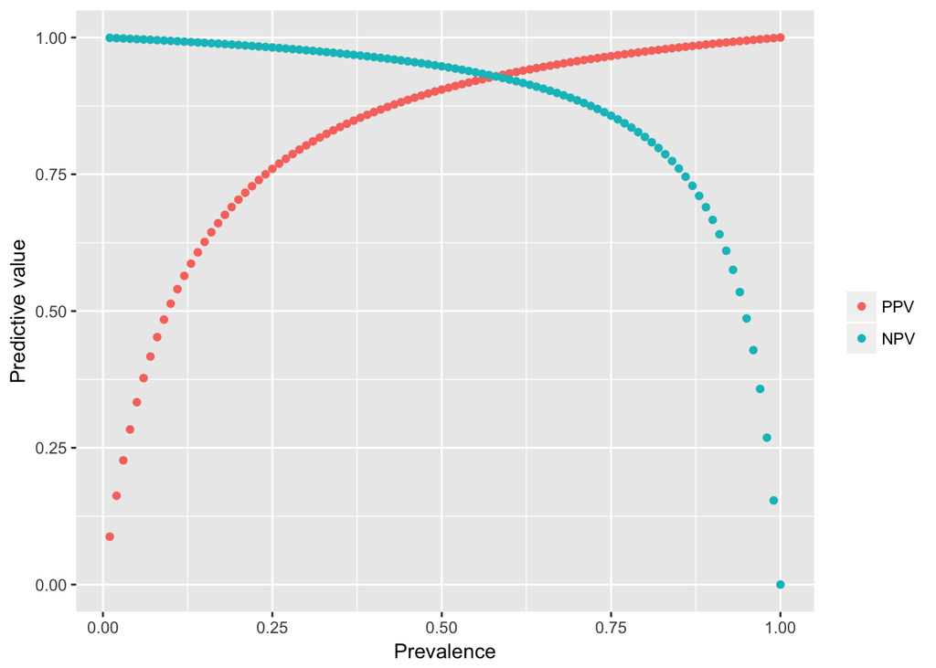

```r
# don't laught and write a better one!
plot_predval <-function(se, sp){
p <- seq(1:100)/100
ppv <- (se*p)/((se*p)+((1-sp)*(1-p)))
npv <- sp*(1-p)/((sp*(1-p)+(1-se)*p))
df <- data.frame(p=c(p,p), pv=c(rep("PPV", length(ppv)),rep("NPV", length(ppv))),
                 pv_value=c(ppv, npv))
df$pv <- factor(df$pv, levels = c("PPV", "NPV"))
ggplot(data=df) + geom_point(aes(x=p, y=pv_value, colour=pv)) +
  labs(x="Prevalence", y="Predictive value", colour="")
}
plot_predval(se=0.95,sp=0.9)
```

### 2. epi_binom

We need a function that takes numbers (successes, total) or data and method for CI calculation.

epi_binom(data, column, method) but also epi_binom(success, total, method)

```r
# currently
dat <- data.frame(Lepto=rbinom(100, 1, 0.05),
                 Brucella=rbinom(100, 1, 0.2),
                 DAge2=rnorm(100, 7, 3),
                 CalfSex= rbinom(100, 1, 0.5))
library(binom)
binom.confint(4, (96+3), 0.95)
```

```
##           method x  n       mean       lower      upper
## 1  agresti-coull 4 99 0.04040404 0.012552856 0.10259000
## 2     asymptotic 4 99 0.04040404 0.001616959 0.07919112
## 3          bayes 4 99 0.04500000 0.009983657 0.08579570
## 4        cloglog 4 99 0.04040404 0.013195727 0.09263083
## 5          exact 4 99 0.04040404 0.011116749 0.10022791
## 6          logit 4 99 0.04040404 0.015247377 0.10273651
## 7         probit 4 99 0.04040404 0.014173157 0.09687366
## 8        profile 4 99 0.04040404 0.012750888 0.09137276
## 9            lrt 4 99 0.04040404 0.012723678 0.09136834
## 10     prop.test 4 99 0.04040404 0.013021875 0.10612509
## 11        wilson 4 99 0.04040404 0.015822639 0.09932021
```

```r
binom.confint(sum(dat$Lepto), nrow(subset(dat, !is.na(Lepto))))
```

```
##           method x   n       mean      lower     upper
## 1  agresti-coull 8 100 0.08000000 0.03899875 0.1520758
## 2     asymptotic 8 100 0.08000000 0.02682751 0.1331725
## 3          bayes 8 100 0.08415842 0.03432262 0.1388420
## 4        cloglog 8 100 0.08000000 0.03740159 0.1435124
## 5          exact 8 100 0.08000000 0.03517156 0.1515576
## 6          logit 8 100 0.08000000 0.04051209 0.1518847
## 7         probit 8 100 0.08000000 0.03897259 0.1474557
## 8        profile 8 100 0.08000000 0.03738928 0.1437994
## 9            lrt 8 100 0.08000000 0.03739644 0.1437984
## 10     prop.test 8 100 0.08000000 0.03767874 0.1561453
## 11        wilson 8 100 0.08000000 0.04109346 0.1499811
```

### 3. epi_confint

I’m a bit lost. This replicates the above. So maybe forget about *epi_binom* and create *epi_confint* which is based on *epi.conf* i.e does estimates and CIs for means, proportions, incidence and standardised mortality ratios.

```r
# currently
library(epiR)
d <- as.matrix(cbind(sum(dat$Lepto),sum(dat$DAge2)),2,1)
d
```

```
##      [,1]     [,2]
## [1,]    8 709.5103
```

```r
epi.conf(dat=d,conf.level=0.95, ctype="inc.rate", method = "exact")
```

```
##          est       lower      upper
## 1 0.01127538 0.005800301 0.02032765
```

```r
# replicates binom.confint
d <- as.matrix(cbind(sum(dat$Lepto), nrow(subset(dat, !is.na(Lepto)))))
epi.conf(dat=d, conf.level = 0.95, ctype = "prevalence", method="exact")
```

```
##    est      lower     upper
## 1 0.08 0.03517156 0.1515576
```

```r
binom.confint(sum(dat$Lepto), nrow(subset(dat, !is.na(Lepto))), methods = "exact")
```

```
##   method x   n mean      lower     upper
## 1  exact 8 100 0.08 0.03517156 0.1515576
```

### 4 epi_2by2

We need a function that takes numbers (a,b,c,d) or data and method for epi estimates.

epi_2by2(data, exposure, response, method) but also epi_2by2(a, b, c, d, method)

Below are examples of all the *methods* used in Mark’s lectures.

```r
#Currently
# cohort.count
m <- table(dat$CalfSex, dat$Lepto)
a <- m[1,2]
b <- m[1,1]
c <- m[2,2]
d <- m[2,1]
leptotable<-matrix(c(a,c,b,d),2,2)
epi.2by2(leptotable, method="cohort.count")
```

```
##              Outcome +    Outcome -      Total        Inc risk *
## Exposed +            4           45         49              8.16
## Exposed -            4           47         51              7.84
## Total                8           92        100              8.00
##                  Odds
## Exposed +      0.0889
## Exposed -      0.0851
## Total          0.0870
##
## Point estimates and 95 % CIs:
## -------------------------------------------------------------------
## Inc risk ratio                               1.04 (0.28, 3.93)
## Odds ratio                                   1.04 (0.25, 4.43)
## Attrib risk *                                0.32 (-10.32, 10.96)
## Attrib risk in population *                  0.16 (-8.94, 9.25)
## Attrib fraction in exposed (%)               3.92 (-263.02, 74.57)
## Attrib fraction in population (%)            1.96 (-90.57, 49.56)
## -------------------------------------------------------------------
##  X2 test statistic: 0.003 p-value: 0.953
##  Wald confidence limits
##  * Outcomes per 100 population units
```

```r
# cohort.time
tab <-dat %>%
  group_by(CalfSex) %>%
  summarise(Dis=sum(Lepto),
            Time=sum(DAge2))
tab
```

```
## # A tibble: 2 x 3
##   CalfSex   Dis     Time
##     <int> <int>    <dbl>
## 1       0     4 377.3020
## 2       1     4 332.2084
```

```r
ir.data <- as.matrix(tab[ ,-1])
epi.2by2(ir.data, method="cohort.time")
```

```
##              Outcome +    Time at risk        Inc rate *
## Exposed +            4             377              1.06
## Exposed -            4             332              1.20
## Total                8             710              1.13
##
## Point estimates and 95 % CIs:
## -------------------------------------------------------------------
## Inc rate ratio                               0.88 (0.16, 4.73)
## Attrib rate *                                -0.14 (-1.72, 1.43)
## Attrib rate in population *                  -0.08 (-1.49, 1.34)
## Attrib fraction in exposed (%)               -13.57 (-509.77, 78.85)
## Attrib fraction in population (%)            -6.79 (-38.76, 15.75)
## -------------------------------------------------------------------
##  X2 test statistic: 0.032 p-value: 0.858
##  Wald confidence limits
##  * Outcomes per 100 units of population time at risk
```

```r
ir.data <- as.table(matrix(c(10, 5, 413, 312),2,2))
epi.2by2(ir.data, method="cohort.time")
```

```
##              Outcome +    Time at risk        Inc rate *
## Exposed +           10             413              2.42
## Exposed -            5             312              1.60
## Total               15             725              2.07
##
## Point estimates and 95 % CIs:
## -------------------------------------------------------------------
## Inc rate ratio                               1.51 (0.47, 5.63)
## Attrib rate *                                0.82 (-1.24, 2.87)
## Attrib rate in population *                  0.47 (-1.29, 2.22)
## Attrib fraction in exposed (%)               33.81 (-112.52, 82.25)
## Attrib fraction in population (%)            22.54 (-9.59, 44.05)
## -------------------------------------------------------------------
##  X2 test statistic: 0.565 p-value: 0.452
##  Wald confidence limits
##  * Outcomes per 100 units of population time at risk
```

```r
# cross sectional
epi.2by2(matrix(c(13,5,2163,3349),2,2), method="cross.sectional")
```

```
##              Outcome +    Outcome -      Total        Prevalence *
## Exposed +           13         2163       2176               0.597
## Exposed -            5         3349       3354               0.149
## Total               18         5512       5530               0.325
##                  Odds
## Exposed +     0.00601
## Exposed -     0.00149
## Total         0.00327
##
## Point estimates and 95 % CIs:
## -------------------------------------------------------------------
## Prevalence ratio                             4.01 (1.43, 11.23)
## Odds ratio                                   4.03 (1.43, 11.31)
## Attrib prevalence *                          0.45 (0.10, 0.80)
## Attrib prevalence in population *            0.18 (-0.02, 0.38)
## Attrib fraction in exposed (%)              75.05 (30.11, 91.09)
## Attrib fraction in population (%)           54.20 (3.61, 78.24)
## -------------------------------------------------------------------
##  X2 test statistic: 8.177 p-value: 0.004
##  Wald confidence limits
##  * Outcomes per 100 population units
```

```r
# case control
```

### epi_tests

Ideally we need the same as above.

epi_tests(data, new_test, gold_standard) but also epi_tests(a, b, c, d)

```r
#Currently takes numbers in a numeric vector
library(epiR)
epi.tests(c(165, 15, 24, 796))
```

```
##           Outcome +    Outcome -      Total
## Test +          165           24        189
## Test -           15          796        811
## Total           180          820       1000
##
## Point estimates and 95 % CIs:
## ---------------------------------------------------------
## Apparent prevalence                    0.19 (0.17, 0.21)
## True prevalence                        0.18 (0.16, 0.21)
## Sensitivity                            0.92 (0.87, 0.95)
## Specificity                            0.97 (0.96, 0.98)
## Positive predictive value              0.87 (0.82, 0.92)
## Negative predictive value              0.98 (0.97, 0.99)
## Positive likelihood ratio              31.32 (21.06, 46.57)
## Negative likelihood ratio              0.09 (0.05, 0.14)
## ---------------------------------------------------------
```

```r
epi.tests(matrix(c(165, 15, 24, 796),2,2))
```

```
##           Outcome +    Outcome -      Total
## Test +          165           24        189
## Test -           15          796        811
## Total           180          820       1000
##
## Point estimates and 95 % CIs:
## ---------------------------------------------------------
## Apparent prevalence                    0.19 (0.17, 0.21)
## True prevalence                        0.18 (0.16, 0.21)
## Sensitivity                            0.92 (0.87, 0.95)
## Specificity                            0.97 (0.96, 0.98)
## Positive predictive value              0.87 (0.82, 0.92)
## Negative predictive value              0.98 (0.97, 0.99)
## Positive likelihood ratio              31.32 (21.06, 46.57)
## Negative likelihood ratio              0.09 (0.05, 0.14)
## ---------------------------------------------------------
```